# General Linear Model

Xiaoying Wang

November 27, 2017

## Ordinary Linear Regression

### model

- $Y$ is $n*1$ vector,
- $X$ is $n*p$ matrix,
- $\beta$ is $p*1$ vector,
- $n$ is the number of observations, $p$ is the umber of features, $p<<n$.
- Assume no multicollinearity exist in $X_i$, or $X$ is non-singular matrix, or $rank(X)=p$

$$Y=X \beta +\epsilon, \epsilon \sim N(0,\sigma^2) iid$$
$$Y\sim N(X\beta ,\sigma^2)$$
$$E(Y)=X\beta$$

### parameter estimation — ordinary least square (OLS)

- loss function: choose $\beta$ s.t. $\sum_{i=1}^{n}(Y_i-\beta_0-X_i\beta_1)^2=(Y-X\beta)^T(Y-X\beta)$ is minimized
- $\hat\beta_{OLS}=(X^TX)^{-1}X^TY$
- properties of OLS: $\hat\beta_{OLS}$ is Best Linear Unbiased Estimator (BLUE) of $\beta$: among all the unbiased estimator of $\beta$, $\hat\beta_{OLS}$ has the smallest variance

## Ridge Regression — deal with multicollinearity

### definition of multicollinearity

- multicollinearity exist if not all $\lambda_1,...,\lambda_k$ exist s.t. $\lambda_1+\lambda_2X_{2i}+...+\lambda_kX_{ki}=0$

### effect of multicollinearity

- since $(X^TX)$ is almost 0, $\hat\beta_{OLS}=(X^TX)^{-1}X^TY$ is getting larger
- increase of the variance of $\hat\beta_{OLS}$,
- increase in confidence interval

### Ridge resression

- add a $l_2$ penalty term on the basis of ordinary linear regression, with loss function
  $$(Y-X\beta)^T(Y-X\beta)+k\beta^2$$
  $$k>0$$
  $$min (Y-X\beta)^T(Y-X\beta), s.t. \sum\beta_j^2<C$$
- $\hat\beta_{k}=(X^TX+kI)^{-1}X^TY$
- as $k$ increases, $\hat\beta_{k}$ is more biased, but variance is getting smaller

## Least Absolute Shrinkage and Selectionator operator (LASSO)

### motivation

- deal with high dimensional data: $p>>n$
- if $p>>n$, $(X^TX)^{-1}=0$, we have infinity number of solutions for $\hat\beta_{OLS}=(X^TX)^{-1}X^TY$. In another word, there’s overfitting

### LASSO

- add a $l_1$ penalty term on the basis of ordinary linear regression, with loss function
  $$(Y-X\beta)^T(Y-X\beta)+k|\beta|$$
  $$min (Y-X\beta)^T(Y-X\beta) s.t. \sum|\beta_j|<C$$
- compare to Ridge regression, LASSO can generate sparsity (eliminate some $X_i$): variable selection

[figure not shown]

## Elastic Net

### loss function

- a compromise between ridge and lasso, or a general case of ridge and lasso
- lasso: elastic net with $\alpha=1$
- ridge: elastic net with $\alpha=0$

## Least Angle Regression

- a variable selection algorithm compromising Forward stepwise regression and forward stagewiseregression

### the basic steps of the Least-angle regression algorithm are:

- Start with all coefficients $\beta _{j}$ equal to zero.
- Find the predictor $x_{j}$ most correlated with $y$
- Increase the coefficient $\beta _{j}$ in the direction of the sign of its correlation with $y$. Take residuals $r=y-\hat {y}$ along the way. Stop when some other predictor $x_{k}$ has as much correlation with $r$ as $x_{j}$ has.
- Increase $(\beta _{j},\beta _{k})$ in their joint least squares direction, until some other predictor $x_{m}$ has as much correlation with the residual $r$.
- Continue until: all predictors are in the model

## When $Y$ are count, categorical variables

### Different of GLM from linear regression

- Response variable $Y$
  - Linear regression: Y follows normal distribution
  - GLM: $Y$ can have arbitrary distributions: binomial, multinomial, possion
- Link funtion g(Y)
  - Linear regression: $g(Y)=Y$, the response Y itself varies linearly with predicted values $X$
  - GLM: a function of $Y$ varies linearly with predicted values $X$, eg: $g(Y)=logit(Y)$ for logistic regression

### Components of GLM

- Distribution of $Y$: probability distribution from exponential family
  - exponential family: a family of pdf(pmf) is called exponention if
    $$f(x|\mathbf{\theta})=h(x)c(\mathbf{\theta})e^{\sum_{i=1}^{k}w_i(\mathbf{\theta})t_i(x)}$$
  - eg.Bernoulli, Binomial,multinomial, Normal, poisson
- Link funtion $g(Y)$
  - $g(Y)=w(Y)$: canonical link
    - $Y\sim Normal(\mu,\sigma^2)$ assume $\sigma$ is known, then $g(Y)=Y$: identical link
    - $Y\sim Bernoulli(p)$ then $g(Y)=log(\frac{Y}{1-Y})$: logit link (logistic regression)
    - $Y\sim Poission(\lambda)$ then $g(Y)=log(Y)$: log link
- Linear system
  - $g(Y)=X\beta$

## Examples

For all examples:

- true model is $y=X\beta+\epsilon$
- where $\epsilon\sim N(0,I)$

### ex1.

Small signal. Lots of noise.

- $\beta=(1,1,0,...,0)^T$, 2s 1, and 498s 0
- $p=500>n=100$
- Uncorrelated predictors:
  $$X_i\sim N(0,I), iid$$

```r
library(MASS)  # Package needed to generate correlated precictors
library(glmnet)  # Package to fit ridge/lasso/elastic net models
# Generate data
set.seed(19875)  # Set seed for reproducibility
n <- 100  # Number of observations
p <- 500  # Number of predictors included in model
real_p <- 2  # Number of true predictors
x <- matrix(rnorm(n*p), nrow=n, ncol=p)
y <- apply(x[,1:real_p], 1, sum) + rnorm(n)

# Split data into train (2/3) and test (1/3) sets
train_rows <- sample(1:n, .66*n)
x.train <- x[train_rows, ]
x.test <- x[-train_rows, ]

y.train <- y[train_rows]
y.test <- y[-train_rows]
```

```r
# Fit models
# (For plots on left):
fit.lasso <- glmnet(x.train, y.train, family="gaussian", alpha=1)
fit.ridge <- glmnet(x.train, y.train, family="gaussian", alpha=0)
fit.elnet <- glmnet(x.train, y.train, family="gaussian", alpha=.5)


# 10-fold Cross validation for each alpha = 0, 0.1, ... , 0.9, 1.0
# (For plots on Right)
for (i in 0:10) {
    assign(paste("fit", i, sep=""), cv.glmnet(x.train, y.train, type.measure="mse",
                                              alpha=i/10,family="gaussian"))
}
```

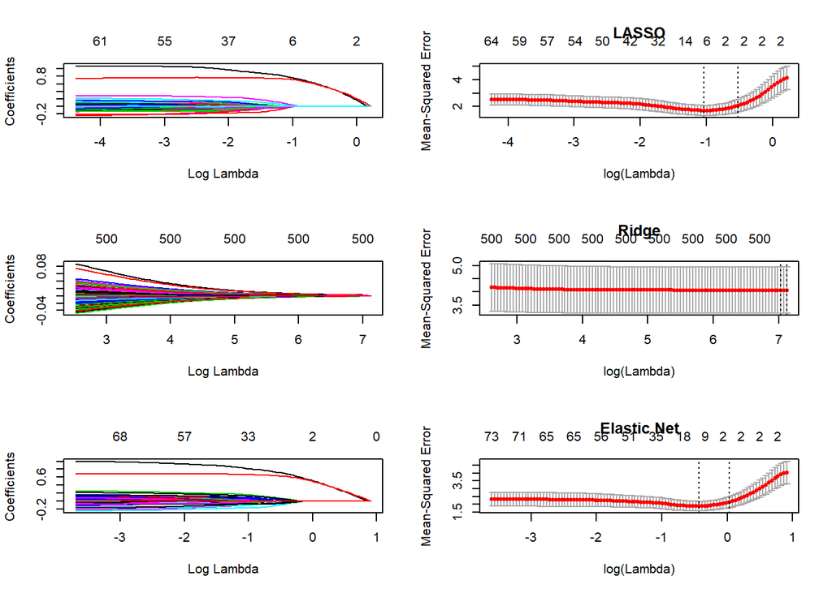

```r
# Plot solution paths:
par(mfrow=c(3,2))
# For plotting options, type '?plot.glmnet' in R console
plot(fit.lasso, xvar="lambda")
plot(fit10, main="LASSO")

plot(fit.ridge, xvar="lambda")
plot(fit0, main="Ridge")

plot(fit.elnet, xvar="lambda")
plot(fit5, main="Elastic Net")
```

```r
yhat0 <- predict(fit0, s=fit0$lambda.1se, newx=x.test)
yhat1 <- predict(fit1, s=fit1$lambda.1se, newx=x.test)
yhat2 <- predict(fit2, s=fit2$lambda.1se, newx=x.test)
yhat3 <- predict(fit3, s=fit3$lambda.1se, newx=x.test)
yhat4 <- predict(fit4, s=fit4$lambda.1se, newx=x.test)
yhat5 <- predict(fit5, s=fit5$lambda.1se, newx=x.test)
yhat6 <- predict(fit6, s=fit6$lambda.1se, newx=x.test)
yhat7 <- predict(fit7, s=fit7$lambda.1se, newx=x.test)
yhat8 <- predict(fit8, s=fit8$lambda.1se, newx=x.test)
yhat9 <- predict(fit9, s=fit9$lambda.1se, newx=x.test)
yhat10 <- predict(fit10, s=fit10$lambda.1se, newx=x.test)

mse0 <- mean((y.test - yhat0)^2)
mse1 <- mean((y.test - yhat1)^2)
mse2 <- mean((y.test - yhat2)^2)
mse3 <- mean((y.test - yhat3)^2)
mse4 <- mean((y.test - yhat4)^2)
mse5 <- mean((y.test - yhat5)^2)
mse6 <- mean((y.test - yhat6)^2)
mse7 <- mean((y.test - yhat7)^2)
mse8 <- mean((y.test - yhat8)^2)
mse9 <- mean((y.test - yhat9)^2)
mse10 <- mean((y.test - yhat10)^2)

mse=c(mse0,mse1,mse2,mse3,mse4,mse5,mse6,mse7,mse8,mse9,mse10)

for(i in 1:length(mse)){
  print(paste('alpha=',(i-1)/10,' ',mse[i]))
  }
```

```
## [1] "alpha= 0   3.56628706537719"
## [1] "alpha= 0.1   3.19596891232558"
## [1] "alpha= 0.2   2.61216305188221"
## [1] "alpha= 0.3   2.23924225313516"
## [1] "alpha= 0.4   2.20375451901338"
## [1] "alpha= 0.5   1.82620374830924"
## [1] "alpha= 0.6   1.91529154172499"
## [1] "alpha= 0.7   1.77983042625268"
## [1] "alpha= 0.8   1.66702662891965"
## [1] "alpha= 0.9   1.62176040215838"
## [1] "alpha= 1   1.69199096356385"
```

### ex2

- Varying signals. High correlation between predictors
- $\beta=(10,10,5,5,1,...,1,0,...,0)$, 10s 1, 36s 0
- $p=50,n=100$
- Correlated predictors: $Cov(X)_{ij}=(0.7)^{|i-j|}$

```r
set.seed(19873)
n <- 100    # Number of observations
p <- 50     # Number of predictors included in model
CovMatrix <- outer(1:p, 1:p, function(x,y) {.7^abs(x-y)})
x <- mvrnorm(n, rep(0,p), CovMatrix)
y <- 10 * apply(x[, 1:2], 1, sum) +
  5 * apply(x[, 3:4], 1, sum) +
  apply(x[, 5:14], 1, sum) +
  rnorm(n)

# Split data into train and test sets
train_rows <- sample(1:n, .66*n)
x.train <- x[train_rows, ]
x.test <- x[-train_rows, ]

y.train <- y[train_rows]
y.test <- y[-train_rows]
```

```r
fit.lasso <- glmnet(x.train, y.train, family="gaussian", alpha=1)
fit.ridge <- glmnet(x.train, y.train, family="gaussian", alpha=0)
fit.elnet <- glmnet(x.train, y.train, family="gaussian", alpha=.5)


# 10-fold Cross validation for each alpha = 0, 0.1, ... , 0.9, 1.0
fit.lasso.cv <- cv.glmnet(x.train, y.train, type.measure="mse", alpha=1,
                          family="gaussian")
fit.ridge.cv <- cv.glmnet(x.train, y.train, type.measure="mse", alpha=0,
                          family="gaussian")
fit.elnet.cv <- cv.glmnet(x.train, y.train, type.measure="mse", alpha=.5,
                          family="gaussian")

for (i in 0:10) {
    assign(paste("fit", i, sep=""), cv.glmnet(x.train, y.train, type.measure="mse",
                                              alpha=i/10,family="gaussian"))
}
```

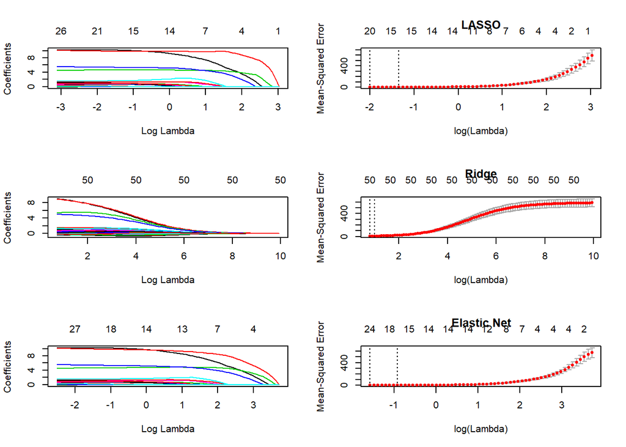

```r
# Plot solution paths:
par(mfrow=c(3,2))
# For plotting options, type '?plot.glmnet' in R console
plot(fit.lasso, xvar="lambda")
plot(fit10, main="LASSO")

plot(fit.ridge, xvar="lambda")
plot(fit0, main="Ridge")

plot(fit.elnet, xvar="lambda")
plot(fit5, main="Elastic Net")
```

```r
yhat0 <- predict(fit0, s=fit0$lambda.1se, newx=x.test)
yhat1 <- predict(fit1, s=fit1$lambda.1se, newx=x.test)
yhat2 <- predict(fit2, s=fit2$lambda.1se, newx=x.test)
yhat3 <- predict(fit3, s=fit3$lambda.1se, newx=x.test)
yhat4 <- predict(fit4, s=fit4$lambda.1se, newx=x.test)
yhat5 <- predict(fit5, s=fit5$lambda.1se, newx=x.test)
yhat6 <- predict(fit6, s=fit6$lambda.1se, newx=x.test)
yhat7 <- predict(fit7, s=fit7$lambda.1se, newx=x.test)
yhat8 <- predict(fit8, s=fit8$lambda.1se, newx=x.test)
yhat9 <- predict(fit9, s=fit9$lambda.1se, newx=x.test)
yhat10 <- predict(fit10, s=fit10$lambda.1se, newx=x.test)

mse0 <- mean((y.test - yhat0)^2)
mse1 <- mean((y.test - yhat1)^2)
mse2 <- mean((y.test - yhat2)^2)
mse3 <- mean((y.test - yhat3)^2)
mse4 <- mean((y.test - yhat4)^2)
mse5 <- mean((y.test - yhat5)^2)
mse6 <- mean((y.test - yhat6)^2)
mse7 <- mean((y.test - yhat7)^2)
mse8 <- mean((y.test - yhat8)^2)
mse9 <- mean((y.test - yhat9)^2)
mse10 <- mean((y.test - yhat10)^2)

mse=c(mse0,mse1,mse2,mse3,mse4,mse5,mse6,mse7,mse8,mse9,mse10)

for(i in 1:length(mse)){
  print(paste('alpha=',(i-1)/10,' ',mse[i]))
  }
```

```
## [1] "alpha= 0   7.92519759000675"
## [1] "alpha= 0.1   1.50176584600985"
## [1] "alpha= 0.2   1.35292777646739"
## [1] "alpha= 0.3   1.47521401946969"
## [1] "alpha= 0.4   1.63366709175348"
## [1] "alpha= 0.5   1.38920912227958"
## [1] "alpha= 0.6   1.42154484495201"
## [1] "alpha= 0.7   1.47923517450038"
## [1] "alpha= 0.8   1.33628162216401"
## [1] "alpha= 0.9   1.53814984148409"
## [1] "alpha= 1   1.54142505118636"
```

## reference

- http://freemind.pluskid.org/machine-learning/sparsity-and-some-basics-of-l1-regularization/
- https://cosx.org/2016/10/data-mining-1-lasso/
- https://web.stanford.edu/~hastie/Papers/ESLII.pdf
- https://en.wikipedia.org/wiki/Least-angle_regression
- https://book.douban.com/annotation/22585258/
- http://www4.stat.ncsu.edu/~post/josh/LASSO_Ridge_Elastic_Net_-_Examples.html
- https://cosx.org/2016/10/data-mining-1-lasso/